# Intervalos de Confianza

Simulación de **Coverage Probability of Confidence Intervals**

```r
library(ggplot2)
library(tidyverse)
library(ggpubr)
```

### Muestras normales estándar

Función que genera un dataframe a partir **N** muestras aleatorias normales de tamaño **n** con probabilidad acumulada **z** (que corresponderá al $z_{1-\frac{\alpha}{2}}$ para los intervalos de confianza). La información contenida en el dataframe es:

1. Número de muestra
2. Tamaño de muestra (n)
3. Media muestral ($\bar{X}$)
4. Desviación estándar ($\sigma$)
5. Error ($\frac{\sigma}{\sqrt{n}}\cdot z_{1-\frac{\alpha}{2}}$) donde $z_{1-\frac{\alpha}{2}}$ es el percentil $1- \frac{\alpha}{2}$ de una $N \sim (0,1)$
6. Límite inferior del intervalo de confianza ($\bar{X} - \frac{\sigma}{\sqrt{n}}\cdot z_{1-\frac{\alpha}{2}}$)
7. Límite superior del IC ($\bar{X} + \frac{\sigma}{\sqrt{n}}\cdot z_{1-\frac{\alpha}{2}}$)

```r
muIC <- function(n=50,N=10000,z=0.975)
{
  set.seed(123)

  df <- data.frame(matrix(NA,n,7))
  colnames(df) <- c('# de muestra','n','media','desv. est.','error','LI','LS')

  for(i in 1:N)
  {
    x <- rnorm(n)    # Creamos una muestra de tamaño N
    mu <- mean(x)
    sigma <- sd(x)
    error <- qnorm(z)*sigma/sqrt(n)

    df[i,1] <- i
    df[i,2] <- n
    df[i,3] <- mu
    df[i,4] <- sigma
    df[i,5] <- error
    df[i,6] <- mu - error
    df[i,7] <- mu + error
  }

  return(df)
}
```

Probamos la función

```r
# IC del 90% = (1-0.1)%
# con percentil de 1-0.05=.95
muNormal <- muIC(z=0.95)
muNormal
```

|  | # de muestra | n | media | desv. est. | error | LI | LS |
| --- | --- | --- | --- | --- | --- | --- | --- |
| 1 | 1 | 50 | 3.440355e-02 | 0.9258700 | 0.2153735 | -1.809699e-01 | 0.2497770454 |
| 2 | 2 | 50 | 1.464083e-01 | 0.9054472 | 0.2106228 | -6.421454e-02 | 0.3570310719 |
| 3 | 3 | 50 | -2.539004e-01 | 0.9893339 | 0.2301363 | -4.840367e-01 | -0.0237641185 |
| 4 | 4 | 50 | 3.880684e-02 | 0.9309750 | 0.2165610 | -1.777542e-01 | 0.2553678529 |
| 5 | 5 | 50 | -8.520539e-03 | 0.9473924 | 0.2203800 | -2.289005e-01 | 0.2118594358 |
| 6 | 6 | 50 | 2.494508e-01 | 0.9441651 | 0.2196293 | 2.982149e-02 | 0.4690800304 |
| 7 | 7 | 50 | 2.054114e-03 | 1.0314509 | 0.2399335 | -2.378793e-01 | 0.2419875647 |
| 8 | 8 | 50 | -7.449993e-02 | 1.0551178 | 0.2454388 | -3.199387e-01 | 0.1709388719 |
| 9 | 9 | 50 | -6.560462e-02 | 1.0271126 | 0.2389243 | -3.045289e-01 | 0.1733196863 |
| 10 | 10 | 50 | 2.773065e-01 | 0.9287796 | 0.2160503 | 6.125614e-02 | 0.4933567965 |

[output cut: 990 more lines]

Función para contar la proporción de muestras cuyos intervalos de confianza contienen al valor del parámetro; es decir, si quisimos un IC del 95% para la muestra entonces el aproximadamente 95% de los IC de las muestras dadas deben contener al parámetro poblacional $\mu = 0$ (pues las muestras son normales estándar)

```r
cuentaCI <- function(dataframe)
{
  n <- dataframe$n
  N <- length(n)
  mu <- dataframe$media
  lower <- dataframe$LI
  upper <- dataframe$LS
  res <- 0
  c <- 0

  for(i in 1:N)
  {

    if(0>=lower[i] & 0<=upper[i])
    {
      c = c + 1
    }
  }

  res <- c/N*100

  return(res)

}
```

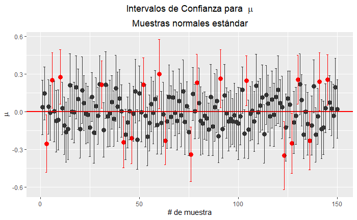

```r
data <- muNormal %>% slice(1:150)
x <- data$`# de muestra`
mu <- data$media
L <- data$LI
U <- data$LS

ggplot(data, aes(x = x, y=mu, color=(L>0 | U<0))) +
  geom_point(size = 3) +
  geom_hline(yintercept = 0, color = 'red', size = 1) +
  geom_errorbar(aes(ymax = U, ymin = L)) +
  scale_colour_manual(values = c('gray20','red')) +
  ggtitle(expression(atop('Intervalos de Confianza para '~mu,paste('\nMuestras normales estándar')))) +
  theme(plot.title = element_text(hjust = 0.5), legend.position = 'none') +
  xlab('# de muestra') +
  ylab(expression(mu))
```

Función para graficar los intervalos de confianza de las muestras dadas

```r
graphCI <- function(df,min=1,max=100)
{
  data <- df %>% slice(min:max)
  x <- data$`# de muestra`
  mu <- data$media
  L <- data$LI
  U <- data$LS

  ggplot(data, aes(x = x, y=mu, color=(L>0 | U<0))) +
    geom_point(size = 3) +
    geom_hline(yintercept = 0, color = 'red', size = 1) +
    geom_errorbar(aes(ymax = U, ymin = L)) +
    scale_colour_manual(values = c('gray20','red')) +
    ggtitle(expression(atop('Intervalos de Confianza para '~mu,paste('\nMuestras normales estándar')))) +
    theme(plot.title = element_text(hjust = 0.5), legend.position = 'none') +
    xlab('# de muestra') +
    ylab(expression(mu))
}
```

Probamos con intervalos de confianza del $50\%$ (con $\alpha=0.5$ y $\frac{\alpha}{2} = 0.25$)

```r
ic50 <- muIC(z=0.75)
ic50
```

|  | # de muestra | n | media | desv. est. | error | LI | LS |
| --- | --- | --- | --- | --- | --- | --- | --- |
| 1 | 1 | 50 | 3.440355e-02 | 0.9258700 | 0.08831620 | -5.391265e-02 | 0.1227197453 |
| 2 | 2 | 50 | 1.464083e-01 | 0.9054472 | 0.08636812 | 6.004014e-02 | 0.2327763923 |
| 3 | 3 | 50 | -2.539004e-01 | 0.9893339 | 0.09436985 | -3.482703e-01 | -0.1595305860 |
| 4 | 4 | 50 | 3.880684e-02 | 0.9309750 | 0.08880315 | -4.999631e-02 | 0.1276099884 |
| 5 | 5 | 50 | -8.520539e-03 | 0.9473924 | 0.09036916 | -9.888970e-02 | 0.0818486170 |
| 6 | 6 | 50 | 2.494508e-01 | 0.9441651 | 0.09006132 | 1.593894e-01 | 0.3395120812 |
| 7 | 7 | 50 | 2.054114e-03 | 1.0314509 | 0.09838727 | -9.633315e-02 | 0.1004413813 |
| 8 | 8 | 50 | -7.449993e-02 | 1.0551178 | 0.10064480 | -1.751447e-01 | 0.0261448644 |
| 9 | 9 | 50 | -6.560462e-02 | 1.0271126 | 0.09797346 | -1.635781e-01 | 0.0323688379 |
| 10 | 10 | 50 | 2.773065e-01 | 0.9287796 | 0.08859374 | 1.887127e-01 | 0.3659002070 |

[output cut: 990 more lines]

```r
cuentaCI(ic50)
```

```
[1] 50.18
```

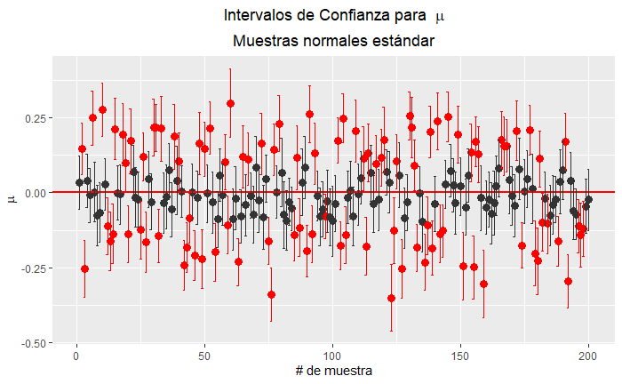

```r
#png(file="nIC_50.png",width = 700, height = 432)
graphCI(ic50,1,200)
```

```r
#dev.off()
```

Probamos con intervalos de confianza del $95\%$ (con $\alpha=0.05$ y $\frac{\alpha}{2} = 0.025$)

```r
ic95 <- muIC(z=0.975)
ic95
```

|  | # de muestra | n | media | desv. est. | error | LI | LS |
| --- | --- | --- | --- | --- | --- | --- | --- |
| 1 | 1 | 50 | 3.440355e-02 | 0.9258700 | 0.2566333 | -0.2222298005 | 0.2910368987 |
| 2 | 2 | 50 | 1.464083e-01 | 0.9054472 | 0.2509726 | -0.1045642821 | 0.3973808184 |
| 3 | 3 | 50 | -2.539004e-01 | 0.9893339 | 0.2742243 | -0.5281247659 | 0.0203238996 |
| 4 | 4 | 50 | 3.880684e-02 | 0.9309750 | 0.2580484 | -0.2192415293 | 0.2968552036 |
| 5 | 5 | 50 | -8.520539e-03 | 0.9473924 | 0.2625989 | -0.2711194760 | 0.2540783977 |
| 6 | 6 | 50 | 2.494508e-01 | 0.9441651 | 0.2617044 | -0.0122536591 | 0.5111551774 |
| 7 | 7 | 50 | 2.054114e-03 | 1.0314509 | 0.2858983 | -0.2838442258 | 0.2879524543 |
| 8 | 8 | 50 | -7.449993e-02 | 1.0551178 | 0.2924584 | -0.3669583032 | 0.2179584411 |
| 9 | 9 | 50 | -6.560462e-02 | 1.0271126 | 0.2846959 | -0.3503004862 | 0.2190912502 |
| 10 | 10 | 50 | 2.773065e-01 | 0.9287796 | 0.2574398 | 0.0198666248 | 0.5347463128 |

[output cut: 990 more lines]

```r
cuentaCI(ic95)
```

```
[1] 94.86
```

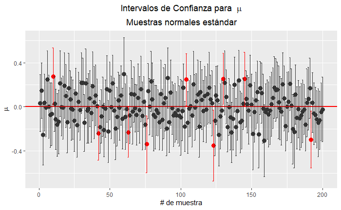

```r
#png(file="nIC_95.png",width = 700, height = 432)
graphCI(ic95,1,200)
```

```r
#dev.off()
```

### Muestras Bernoulli

Función que genera un dataframe a partir **N** muestras aleatorias $bernoullis(\theta)$ de tamaño **n** con con probabilidad acumulada **z** (que corresponderá al $z_{1-\frac{\alpha}{2}}$ para los intervalos de confianza). La información contenida en el dataframe es:

1. Número de muestra
2. Tamaño de muestra (n)
3. Theta de la distribución ($\theta$)
4. Media muestral ($\bar{X}$)
5. Desviación estándar ($\sqrt{\frac{\bar{X}(1-\bar{X})}{n}}$)
6. Error ($\sqrt{\frac{\bar{X}(1-\bar{X})}{n}} \cdot z_{1-\frac{\alpha}{2}}$) donde $z_{1-\frac{\alpha}{2}}$ es el percentil $1- \frac{\alpha}{2}$ de una $N \sim (0,1)$
7. Límite inferior del intervalo de confianza ($\bar{X} - \sqrt{\frac{\bar{X}(1-\bar{X})}{n}} \cdot z_{1-\frac{\alpha}{2}}$)
8. Límite superior del IC ($\bar{X} + \sqrt{\frac{\bar{X}(1-\bar{X})}{n}} \cdot z_{1-\frac{\alpha}{2}}$)

```r
bmuIC <- function(n=50,N=10000,p=0.2,z=0.975)
{
  set.seed(123)

  df <- data.frame(matrix(NA,n,8))
  colnames(df) <- c('# de muestra','n','theta','media','desv. est.','error','LI','LS')

  for(i in 1:N)
  {
    x <- sample(c(0,1),size=n,replace = TRUE, prob = c(1-p,p))   # Creamos una muestra de tamaño N
    mu <- mean(x)
    sigma <- sqrt(mu*(1-mu)/n)
    error <- qnorm(z)*sigma

    df[i,1] <- i
    df[i,2] <- n
    df[i,3] <- p
    df[i,4] <- mu
    df[i,5] <- sigma
    df[i,6] <- error
    df[i,7] <- mu - error
    df[i,8] <- mu + error
  }

  return(df)
}
```

```r
bcuentaCI <- function(dataframe)
{
  p <- dataframe$theta[1]
  n <- dataframe$n
  N <- length(n)
  mu <- dataframe$media
  lower <- dataframe$LI
  upper <- dataframe$LS
  res <- 0
  c <- 0

  for(i in 1:N)
  {

    if(p>=lower[i] & p<=upper[i])
    {
      c = c + 1
    }
  }

  res <- c/N*100

  return(res)

}
```

Función para graficar los intervalos de confianza de las muestras dadas

```r
bgraphCI <- function(df,min=1,max=100)
{
  data <- df %>% slice(min:max)
  x <- data$`# de muestra`
  mu <- data$media
  p <- data$theta[1]
  L <- data$LI
  U <- data$LS

  ggplot(data, aes(x = x, y=mu, color=(L>p | U<p))) +
    geom_point(size = 3) +
    geom_hline(yintercept = p, color = 'red', size = 1) +
    geom_errorbar(aes(ymax = U, ymin = L)) +
    scale_colour_manual(values = c('gray20','red')) +
    ggtitle(expression(atop('Intervalos de Confianza para '~theta,paste('\nMuestras Bernoullis')))) +
    theme(plot.title = element_text(hjust = 0.5), legend.position = 'none') +
    xlab('# de muestra') +
    ylab(expression(theta))
}
```

Probamos con intervalos de confianza del $95\%$ (con $\alpha=0.05$ y $\frac{\alpha}{2} = 0.025$) y con $\theta = 0.4$

```r
b_ic95 <- bmuIC(p=0.4, z=0.975)
b_ic95
```

|  | # de muestra | n | theta | media | desv. est. | error | LI | LS |
| --- | --- | --- | --- | --- | --- | --- | --- | --- |
| 1 | 1 | 50 | 0.4 | 0.40 | 0.06928203 | 0.1357903 | 0.26420971 | 0.5357903 |
| 2 | 2 | 50 | 0.4 | 0.40 | 0.06928203 | 0.1357903 | 0.26420971 | 0.5357903 |
| 3 | 3 | 50 | 0.4 | 0.42 | 0.06979971 | 0.1368049 | 0.28319508 | 0.5568049 |
| 4 | 4 | 50 | 0.4 | 0.34 | 0.06699254 | 0.1313030 | 0.20869704 | 0.4713030 |
| 5 | 5 | 50 | 0.4 | 0.42 | 0.06979971 | 0.1368049 | 0.28319508 | 0.5568049 |
| 6 | 6 | 50 | 0.4 | 0.36 | 0.06788225 | 0.1330468 | 0.22695323 | 0.4930468 |
| 7 | 7 | 50 | 0.4 | 0.42 | 0.06979971 | 0.1368049 | 0.28319508 | 0.5568049 |
| 8 | 8 | 50 | 0.4 | 0.36 | 0.06788225 | 0.1330468 | 0.22695323 | 0.4930468 |
| 9 | 9 | 50 | 0.4 | 0.36 | 0.06788225 | 0.1330468 | 0.22695323 | 0.4930468 |
| 10 | 10 | 50 | 0.4 | 0.42 | 0.06979971 | 0.1368049 | 0.28319508 | 0.5568049 |

[output cut: 990 more lines]

```r
bcuentaCI(b_ic95)
```

```
[1] 94.05
```

```r
png(file="bIC_95-4.png",width = 700, height = 432)
bgraphCI(b_ic95,1,200)
dev.off()
```

Probamos con intervalos de confianza del $95\%$ (con $\alpha=0.05$ y $\frac{\alpha}{2} = 0.025$) y con $\theta = 0.9$

```r
b_ic95 <- bmuIC(p=0.9, z=0.975)
b_ic95
```

|  | # de muestra | n | theta | media | desv. est. | error | LI | LS |
| --- | --- | --- | --- | --- | --- | --- | --- | --- |
| 1 | 1 | 50 | 0.9 | 0.88 | 0.04595650 | 0.09007309 | 0.7899269 | 0.9700731 |
| 2 | 2 | 50 | 0.9 | 0.98 | 0.01979899 | 0.03880531 | 0.9411947 | 1.0188053 |
| 3 | 3 | 50 | 0.9 | 0.86 | 0.04907138 | 0.09617813 | 0.7638219 | 0.9561781 |
| 4 | 4 | 50 | 0.9 | 0.92 | 0.03836665 | 0.07519726 | 0.8448027 | 0.9951973 |
| 5 | 5 | 50 | 0.9 | 0.88 | 0.04595650 | 0.09007309 | 0.7899269 | 0.9700731 |
| 6 | 6 | 50 | 0.9 | 0.92 | 0.03836665 | 0.07519726 | 0.8448027 | 0.9951973 |
| 7 | 7 | 50 | 0.9 | 0.92 | 0.03836665 | 0.07519726 | 0.8448027 | 0.9951973 |
| 8 | 8 | 50 | 0.9 | 0.86 | 0.04907138 | 0.09617813 | 0.7638219 | 0.9561781 |
| 9 | 9 | 50 | 0.9 | 0.90 | 0.04242641 | 0.08315423 | 0.8168458 | 0.9831542 |
| 10 | 10 | 50 | 0.9 | 0.92 | 0.03836665 | 0.07519726 | 0.8448027 | 0.9951973 |

[output cut: 990 more lines]

```r
bcuentaCI(b_ic95)
```

```
[1] 88
```

```r
png(file="bIC_95-9.png",width = 700, height = 432)
bgraphCI(b_ic95,1,200)
dev.off()
```

Probamos con intervalos de confianza del $50\%$ (con $\alpha=0.5$ y $\frac{\alpha}{2} = 0.25$) y con $\theta = 0.2$

```r
b_ic50 <- bmuIC(p=0.2, z=0.75)
b_ic50
```

|  | # de muestra | n | theta | media | desv. est. | error | LI | LS |
| --- | --- | --- | --- | --- | --- | --- | --- | --- |
| 1 | 1 | 50 | 0.2 | 0.22 | 0.05858327 | 0.03951382 | 0.18048618 | 0.25951382 |
| 2 | 2 | 50 | 0.2 | 0.14 | 0.04907138 | 0.03309814 | 0.10690186 | 0.17309814 |
| 3 | 3 | 50 | 0.2 | 0.22 | 0.05858327 | 0.03951382 | 0.18048618 | 0.25951382 |
| 4 | 4 | 50 | 0.2 | 0.16 | 0.05184593 | 0.03496955 | 0.12503045 | 0.19496955 |
| 5 | 5 | 50 | 0.2 | 0.20 | 0.05656854 | 0.03815490 | 0.16184510 | 0.23815490 |
| 6 | 6 | 50 | 0.2 | 0.18 | 0.05433231 | 0.03664659 | 0.14335341 | 0.21664659 |
| 7 | 7 | 50 | 0.2 | 0.18 | 0.05433231 | 0.03664659 | 0.14335341 | 0.21664659 |
| 8 | 8 | 50 | 0.2 | 0.20 | 0.05656854 | 0.03815490 | 0.16184510 | 0.23815490 |
| 9 | 9 | 50 | 0.2 | 0.18 | 0.05433231 | 0.03664659 | 0.14335341 | 0.21664659 |
| 10 | 10 | 50 | 0.2 | 0.20 | 0.05656854 | 0.03815490 | 0.16184510 | 0.23815490 |

[output cut: 990 more lines]

```r
bcuentaCI(b_ic50)
```

```
[1] 50.38
```

```r
png(file="bIC_50-2.png",width = 700, height = 432)
bgraphCI(b_ic50,1,200)
dev.off()
```

Probamos con intervalos de confianza del $25\%$ (con $\alpha=0.75$ y $\frac{\alpha}{2} = 0.375$) y con $\theta = 0.2$

```r
b_ic25 <- bmuIC(p=0.2, z=0.625)
b_ic25
```

|  | # de muestra | n | theta | media | desv. est. | error | LI | LS |
| --- | --- | --- | --- | --- | --- | --- | --- | --- |
| 1 | 1 | 50 | 0.2 | 0.22 | 0.05858327 | 0.018666937 | 0.20133306 | 0.23866694 |
| 2 | 2 | 50 | 0.2 | 0.14 | 0.04907138 | 0.015636072 | 0.12436393 | 0.15563607 |
| 3 | 3 | 50 | 0.2 | 0.22 | 0.05858327 | 0.018666937 | 0.20133306 | 0.23866694 |
| 4 | 4 | 50 | 0.2 | 0.16 | 0.05184593 | 0.016520153 | 0.14347985 | 0.17652015 |
| 5 | 5 | 50 | 0.2 | 0.20 | 0.05656854 | 0.018024964 | 0.18197504 | 0.21802496 |
| 6 | 6 | 50 | 0.2 | 0.18 | 0.05433231 | 0.017312413 | 0.16268759 | 0.19731241 |
| 7 | 7 | 50 | 0.2 | 0.18 | 0.05433231 | 0.017312413 | 0.16268759 | 0.19731241 |
| 8 | 8 | 50 | 0.2 | 0.20 | 0.05656854 | 0.018024964 | 0.18197504 | 0.21802496 |
| 9 | 9 | 50 | 0.2 | 0.18 | 0.05433231 | 0.017312413 | 0.16268759 | 0.19731241 |
| 10 | 10 | 50 | 0.2 | 0.20 | 0.05656854 | 0.018024964 | 0.18197504 | 0.21802496 |

[output cut: 990 more lines]

```r
bcuentaCI(b_ic25)
```

```
[1] 13.35
```

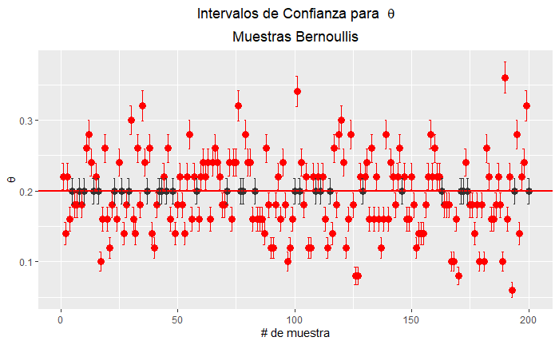

```r
#png(file="bIC_25-2.png",width = 700, height = 432)
bgraphCI(b_ic25,1,200)
```

```r
#dev.off()
```

### Covertura del Intervalo Wald

Función que define el intervalo de confianza

```r
icWald <- function(success=50,n=100,alpha=0.95)
{
  df <- data.frame(matrix(NA,ncol=2))

  p <- success/n
  sd <- sqrt(p*(1-p)/n)
  z <- qnorm(1-(1-alpha)/2)
  df[1] <- p - z*sd
  df[2]<- p + z*sd

  return(df)
}
```

Función que da un dataframe con la probabilidad, el % de cobertura del IC de la muestra binomial de tamaño n

```r
dfWald <- function(n=50,N=10000,aConf=0.95)
{
  set.seed(123)
  probs <- seq(0.001,0.999,0.01)
  df <- data.frame(matrix(NA,ncol=4,nrow = probs))
  names(df) <- c('Probabilidad','% de cobertura','% del IC','Tamaño de muestra')
  isCovered <- as.numeric()

  for(i in 1:length(probs))
  {
    df[i,1] <- probs[i]
    x <- rbinom(n=N,size=n,prob=probs[i])
    for(j in 1:N)
    {
      ci <- icWald(success=x[j],n=n,alpha=aConf)
      isCovered[j] <- (ci[1]< probs[i]) & (probs[i]<ci[2])
    }
    df[i,2] <- mean(isCovered)*100
    df[i,3] <- aConf*100
    df[i,4] <- n
  }
  return(df)
}
```

Función que grafica el % de cobertura real para el IC del % deseado para una muestra binomial de tamaño n

```r
gWald <- function(df)
{
  p <- df$Probabilidad
  cob <- df$`% de cobertura`
  ic <- df$`% del IC`[1]
  n <- df$`Tamaño de muestra`[1]

  myTitle <- paste('Cobertura real para el IC binomial del ',ic,'% para n=',n)

  g <- ggplot(df, aes(x=p,y=cob)) + geom_line(color='black',size=0.8) +
        geom_hline(yintercept = ic, linetype='solid',color='red',size=0.8) +
        ggtitle(myTitle) +
        theme(plot.title = element_text(hjust = 0.5)) +
        ylab('% de cobertura') +
        xlab(expression(theta)) +
        coord_cartesian(ylim=c(75,100))  # Tomamos del 75 al 100%

  return(g)
}
```

Gráficas individuales: Cobertura real del IC binomial del **95%** para una muestra de **n=10**

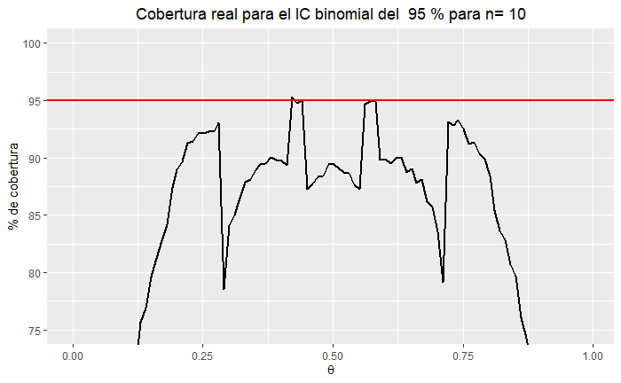

```r
wIC10 <- dfWald(n=10)

#png(file="wIC_10.png",width = 700, height = 432)
gWald(wIC10)
```

```r
#dev.off()
```

Cobertura real del IC binomial del **95%** para una muestra de **n=30**

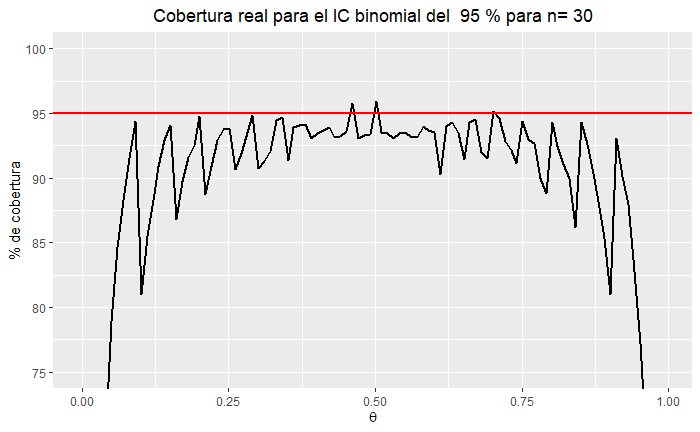

```r
wIC30 <- dfWald(n=30)

#png(file="wIC_30.png",width = 700, height = 432)
gWald(wIC30)
```

```r
#dev.off()
```

Cobertura real del IC binomial del **95%** para una muestra de **n=50**

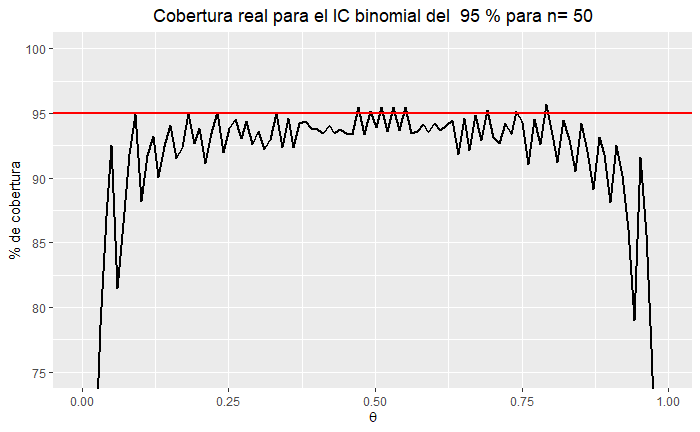

```r
wIC50 <- dfWald(n=50)

#png(file="wIC_50.png",width = 700, height = 432)
gWald(wIC50)
```

```r
#dev.off()
```

Cobertura real del IC binomial del **95%** para una muestra de **n=100**

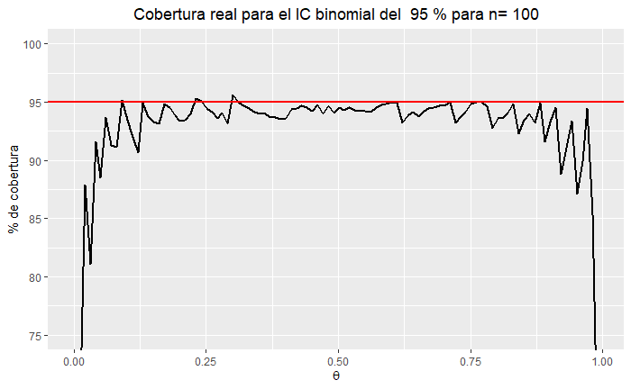

```r
wIC100 <- dfWald(n=100)

#png(file="wIC_100.png",width = 700, height = 432)
gWald(wIC100)
```

```r
#dev.off()
```

Juntamos las gráficas

Primero necesitamos quitarles el título

```r
gWald_all <- function(df)
{
  p <- df$Probabilidad
  cob <- df$`% de cobertura`
  ic <- df$`% del IC`[1]
  n <- df$`Tamaño de muestra`[1]

  myTitle <- paste('n=',n)

  g <- ggplot(df, aes(x=p,y=cob)) + geom_line(color='black',size=0.8) +
        geom_hline(yintercept = ic, linetype='solid',color='red',size=0.8) +
        ggtitle(myTitle) +
        theme(plot.title = element_text(hjust = 0.5)) +
        ylab('% de cobertura') +
        xlab(expression(theta)) +
        coord_cartesian(ylim=c(75,100))  # Tomamos del 75 al 100%

  return(g)
}
```

Ahora generamos las gráficas individuales

```r
#wIC10 <- dfWald(n=10)
gwIC10 <- gWald_all(wIC10)

#wIC30 <- dfWald(n=30)
gwIC30 <- gWald_all(wIC30)

#wIC50 <- dfWald(n=50)
gwIC50 <- gWald_all(wIC50)

#wIC100 <- dfWald(n=100)
gwIC100 <- gWald_all(wIC100)
```

Para juntar todas las gráficas en un solo plot

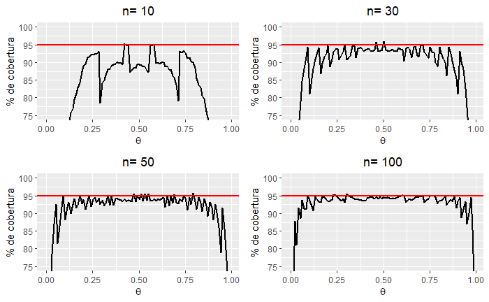

```r
gAll <- ggarrange(gwIC10,gwIC30,gwIC50,gwIC100,
          ncol = 2, nrow = 2)

#png(file="wIC_all.png",width = 700, height = 432)
gAll
```

```r
#dev.off()
```